# TITANIC: Análise do Náufrago

### Objetivo

Este projeto tem como objetivo, analisar alguns dados do naufrágio do navio Titanic. Utilizando o dataframe `titanic-data-6.csv`, iremos responder algumas perguntas que pode ser extraídas do banco de dados. Primeiramente, uma breve contextualização sobre o Navio Titanic.

### Uma breve história sobre o Titanic

Construido no início do século XX, o RMS TITANIC (mais conhecido com Titanic) foi um navio de passageiros pensado para ser o navio mais luxuoso da época. Com 269 metros de comprimento e 28 metros de altura era um dos maiores transatlântico da época.

Partindo de Southampton (Nova Iorque) em 10 de abri de 1912, passando em Cherboung-Octeville (França) e por Queenstown (Irlanda).

No dia 14 de abril de 1912 às 23h40min, colidiu com um iceberg causando a morte de mais de 1500 pessoas a bordo.

## Iniciando as Análises

Para melhor entendimento dos dados do dataframe `titanic-data-6.csv`, utilizaremos o site www.kaggle.com/c/titanic/data como guia.

### 1 - Dicionário dos Dados

###### PassegerId:

Identificação crescente dos passageros, começando do número 1;

###### Survived:

Mostra se o passageiro não sobreviveu ('0') ou sobreviveu ('1');

###### Pclass:

Mostra se o passageiro era da 1ª classe ('1'), 2ª classe ('2') ou 3ª classe ('3');

###### Name:

Nome do passageiro;

###### Sex:

Sexo do passageiro;

###### Age:

Idade do passageiro;

###### SibSp:

Quantidade de irmãos / cônjuges abordo do Titanic;

###### Parch:

Quantidade de pais / filhos abordo do Titanic;

###### Ticket:

Número do Ticket;

###### Fare:

Tarifa do passageiro (valor da passagem);

###### Cabin:

Número da cabine do passageiro;

###### Embarked:

Mostra qual foi o porto de embarque do passageiro. Sendo C = Cherbourg, Q = Queenstown, S = Southampton.

### 2 - Explorando o Dataframe

```python
#importando as bibliotecas
import pandas as pd
import numpy as np
%matplotlib inline
import matplotlib.pyplot as plt
```

```python
#importanto o conjunto de dados do arquivo 'titanic-data-6.csv'
df = pd.read_csv('titanic-data-6.csv')
```

```python
#pre-visualização do dataframe
df.head()
```

|  | PassengerId | Survived | Pclass | Name | Sex | Age | SibSp | Parch | Ticket | Fare | Cabin | Embarked |
| --- | --- | --- | --- | --- | --- | --- | --- | --- | --- | --- | --- | --- |
| 0 | 1 | 0 | 3 | Braund, Mr. Owen Harris | male | 22.0 | 1 | 0 | A/5 21171 | 7.2500 | NaN | S |
| 1 | 2 | 1 | 1 | Cumings, Mrs. John Bradley (Florence Briggs Th... | female | 38.0 | 1 | 0 | PC 17599 | 71.2833 | C85 | C |
| 2 | 3 | 1 | 3 | Heikkinen, Miss. Laina | female | 26.0 | 0 | 0 | STON/O2. 3101282 | 7.9250 | NaN | S |
| 3 | 4 | 1 | 1 | Futrelle, Mrs. Jacques Heath (Lily May Peel) | female | 35.0 | 1 | 0 | 113803 | 53.1000 | C123 | S |
| 4 | 5 | 0 | 3 | Allen, Mr. William Henry | male | 35.0 | 0 | 0 | 373450 | 8.0500 | NaN | S |

```python
print("Número de Linhas no Dataframe: {0} \nNúmero de Colunas no Dataframe: {1}".format(df.shape[0], df.shape[1]))
```

```
Número de Linhas no Dataframe: 891
Número de Colunas no Dataframe: 12
```

```python
#visualizando os tipos de dados presentes em cada coluna
df.dtypes
```

```
PassengerId      int64
Survived         int64
Pclass           int64
Name            object
Sex             object
Age            float64
SibSp            int64
Parch            int64
Ticket          object
Fare           float64
Cabin           object
Embarked        object
dtype: object
```

```python
#verificando dados nulos
df.isnull().sum()
```

```
PassengerId      0
Survived         0
Pclass           0
Name             0
Sex              0
Age            177
SibSp            0
Parch            0
Ticket           0
Fare             0
Cabin          687
Embarked         2
dtype: int64
```

###### Atráves da função isnull e sum, é mostrado a soma dos valores nulos por coluna

No campo da idade temos 177 valores nulos;

No campo Cabine temos 687 valores nulos;

No campo Embarque temos 2 valores nulos.

### 3 - Limpeza do Dataframe para Melhor Compreensão

```python
#removendo colunas que não serão importante para o processo de análise
df.drop(['PassengerId', 'Ticket', 'Cabin'], axis=1, inplace=True)
```

```python
#remoneando as colunas (para português)
df.columns = ['sobreviveu','classe','nome','sexo','idade','irmaos_conjuges','pais_filhos','tarifa','embarque']
df.head()
```

|  | sobreviveu | classe | nome | sexo | idade | irmaos_conjuges | pais_filhos | tarifa | embarque |
| --- | --- | --- | --- | --- | --- | --- | --- | --- | --- |
| 0 | 0 | 3 | Braund, Mr. Owen Harris | male | 22.0 | 1 | 0 | 7.2500 | S |
| 1 | 1 | 1 | Cumings, Mrs. John Bradley (Florence Briggs Th... | female | 38.0 | 1 | 0 | 71.2833 | C |
| 2 | 1 | 3 | Heikkinen, Miss. Laina | female | 26.0 | 0 | 0 | 7.9250 | S |
| 3 | 1 | 1 | Futrelle, Mrs. Jacques Heath (Lily May Peel) | female | 35.0 | 1 | 0 | 53.1000 | S |
| 4 | 0 | 3 | Allen, Mr. William Henry | male | 35.0 | 0 | 0 | 8.0500 | S |

```python
#função para formatar os dados do dataframe, tendo como entrada o dataframe a ser formatado e saida o dataframe formatado
def formata_dados(banco_dados):

    #traduzindo os sexos:
    banco_dados['sexo'] = banco_dados['sexo'].replace(['male','female'],['masculino','feminino'])

    #tracando as abreviações dos locais de embarque pelo nome completo:
    banco_dados['embarque'] = banco_dados['embarque'].replace(['C','Q','S'],['Cherbourg','Queenstown','Southampton'])

    #trocando '0' por nao e '1' por sim:
    banco_dados['sobreviveu'] = banco_dados['sobreviveu'].replace([0,1],['nao','sim'])

    #trocando "1" por primeira_classe, "2" por segunda_classe e "3" por terceira_classe
    banco_dados['classe'] = banco_dados['classe'].replace([1,2,3],['primeira_classe','segunda_classe','terceira_classe'])

    return banco_dados
```

```python
#utilizando a função para formatar os dados
df = formata_dados(df)
```

```python
#verificando como ficou os dados formatados
df.head()
```

|  | sobreviveu | classe | nome | sexo | idade | irmaos_conjuges | pais_filhos | tarifa | embarque |
| --- | --- | --- | --- | --- | --- | --- | --- | --- | --- |
| 0 | nao | terceira_classe | Braund, Mr. Owen Harris | masculino | 22.0 | 1 | 0 | 7.2500 | Southampton |
| 1 | sim | primeira_classe | Cumings, Mrs. John Bradley (Florence Briggs Th... | feminino | 38.0 | 1 | 0 | 71.2833 | Cherbourg |
| 2 | sim | terceira_classe | Heikkinen, Miss. Laina | feminino | 26.0 | 0 | 0 | 7.9250 | Southampton |
| 3 | sim | primeira_classe | Futrelle, Mrs. Jacques Heath (Lily May Peel) | feminino | 35.0 | 1 | 0 | 53.1000 | Southampton |
| 4 | nao | terceira_classe | Allen, Mr. William Henry | masculino | 35.0 | 0 | 0 | 8.0500 | Southampton |

```python
#verificando agora como ficou o tipo d o dados
df.dtypes
```

```
sobreviveu          object
classe              object
nome                object
sexo                object
idade              float64
irmaos_conjuges      int64
pais_filhos          int64
tarifa             float64
embarque            object
dtype: object
```

```python
#retornando os valores unicos de cada coluna
df.nunique()
```

```
sobreviveu           2
classe               3
nome               891
sexo                 2
idade               88
irmaos_conjuges      7
pais_filhos          7
tarifa             248
embarque             3
dtype: int64
```

### 4 - Análise

#### 4.0 Análises Básicas

```python
#extraindo algumas informações estátisticas básicas
df.describe()
```

|  | idade | irmaos_conjuges | pais_filhos | tarifa |
| --- | --- | --- | --- | --- |
| count | 714.000000 | 891.000000 | 891.000000 | 891.000000 |
| mean | 29.699118 | 0.523008 | 0.381594 | 32.204208 |
| std | 14.526497 | 1.102743 | 0.806057 | 49.693429 |
| min | 0.420000 | 0.000000 | 0.000000 | 0.000000 |
| 25% | 20.125000 | 0.000000 | 0.000000 | 7.910400 |
| 50% | 28.000000 | 0.000000 | 0.000000 | 14.454200 |
| 75% | 38.000000 | 1.000000 | 0.000000 | 31.000000 |
| max | 80.000000 | 8.000000 | 6.000000 | 512.329200 |

###### Atráves da função describe, podemos tirar algumas conclusões dos dados:

```
1º) Podemos ver que o passageiro mais velho a bordo tinha 80 anos e o mais novo tinha um pouco mais de 0,42 anos;
2º) A maior tarifa paga por um passageiro foi de 512.3292 e a menor foi de graça (como no dataframe não temos informações de quem era passageiro e quem era tripulação, possivelmente está tarifa de graça era dos tripulantes);
3º) Na categoria Irmães/Cônjuges, teve passageiros que levaram 8 pessoas consigo.
4º) Na categoria Pais/Filhos, teve passageiros que levaram 6 pessoas consigo.
```

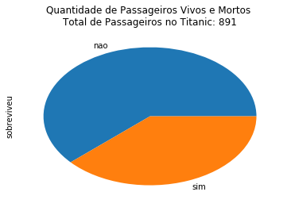

```
Quantidade de Passageiros Vivos e Mortos
nao    549
sim    342
Name: sobreviveu, dtype: int64
```

```python
#Verificando os sobreviventes e os mortos
passageiros = df['sobreviveu'].value_counts()
passageiros.plot(kind='pie')
plt.title('Quantidade de Passageiros Vivos e Mortos \nTotal de Passageiros no Titanic: {0}'.format(df.shape[0]))
plt.show()
print('Quantidade de Passageiros Vivos e Mortos')
print(passageiros)
```

#### 4.1 Análise por Sexo e Classe

Qual sexo teve a maior proporção de sobreviventes?

Será que a classe que o passageiro estava influenciou em sua sobrevivência?

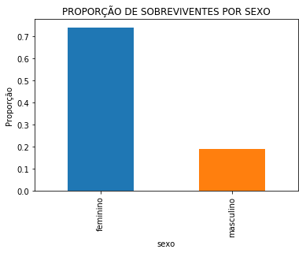

```
PROPORÇÃO DE SOBREVIVENTES POR SEXO
sexo
feminino     0.742038
masculino    0.188908
Name: sobreviveu, dtype: float64
```

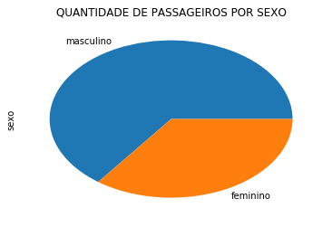

```
QUANTIDADE DE PASSAGEIROS POR SEXO
masculino    577
feminino     314
Name: sexo, dtype: int64
```

```python
#agrupando os sexos para verificar a proporção de sobreviventes
df.groupby('sexo')['sobreviveu'].apply(lambda x: np.mean(x == 'sim')).plot(kind='bar')
plt.title('PROPORÇÃO DE SOBREVIVENTES POR SEXO')
plt.ylabel('Proporção')
plt.show()

print('PROPORÇÃO DE SOBREVIVENTES POR SEXO')
print(df.groupby('sexo')['sobreviveu'].apply(lambda x: np.mean(x == 'sim')))

passageiros_sexo = df['sexo'].value_counts()
passageiros_sexo.plot(kind='pie')
plt.title('QUANTIDADE DE PASSAGEIROS POR SEXO')
plt.show()

print('QUANTIDADE DE PASSAGEIROS POR SEXO')
print(passageiros_sexo)
```

Podemos ver que entre todas as mulheres presentes na tragédia, 74,2038% delas sobreviveram. Porém apenas 18,8908% dos homens presentes tiveram a sorte de sobreviver.

Nesta analise, somente foi considerado o sexo de cada passageiro, não importando a idade ou classe social (que serão analisados posteriormente).

Observação: é bom lembrar que estamos trabalhando com uma base de dados que não corresponde totalmente o número de passageiros presentes no Titanic.

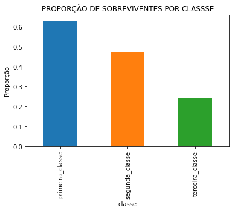

```
classe
primeira_classe    0.629630
segunda_classe     0.472826
terceira_classe    0.242363
Name: sobreviveu, dtype: float64
```

```python
#agrupando os sobreviventes por classe "social", independente do sexo ou idade, para verificar a proporção
df.groupby('classe')['sobreviveu'].apply(lambda x: np.mean(x == 'sim')).plot(kind='bar')
plt.title('PROPORÇÃO DE SOBREVIVENTES POR CLASSSE')
plt.ylabel('Proporção')
plt.show()

df.groupby('classe')['sobreviveu'].apply(lambda x: np.mean(x == 'sim'))
```

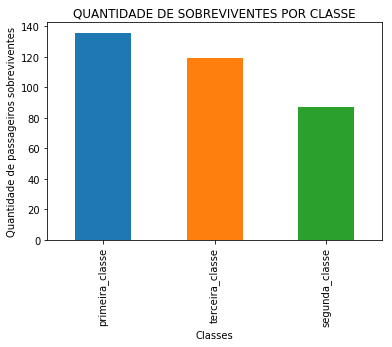

```
Sobreviventes por classe
primeira_classe    136
terceira_classe    119
segunda_classe      87
Name: classe, dtype: int64
```

```python
sobreviveu_classe = df[df['sobreviveu'] == 'sim']['classe'].value_counts()
sobreviveu_classe.plot(kind='bar')
plt.title('QUANTIDADE DE SOBREVIVENTES POR CLASSE')
plt.xlabel('Classes')
plt.ylabel('Quantidade de passageiros sobreviventes')
plt.show()
#quantidade de sobreviventes por classe
print("Sobreviventes por classe")
print(sobreviveu_classe)
```

Proporcionalmente, entre os passageiros da primeira classe temos a maior proporção de sobreviventes (com 62,9630%), possivelmente pelo motivo de que as cabines da primeira classe ficam mais próximas dos botes salva-vidas.

E entre todos os passageiros da terceira classe temos a menor proporção de sobrevivente(24,2363% de todos os passageiros da terceira classe sobreviveram).

Mas o mais interessante é que quando analisamos o número de sobreviventes por classe, vemos que a quantidade de passageiros da terceira classe que sobreviveram é mais que a da segunda classe, ou seja, tinhamos no navio mais pessoas na terceira classe do que na segunda, como podemos ver abaixo:

```
Passageiros por Classe
terceira_classe    491
primeira_classe    216
segunda_classe     184
Name: classe, dtype: int64
```

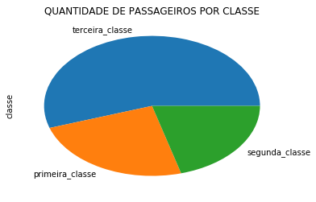

```python
#quantidade de passageiros por classe
print('Passageiros por Classe')
passageiros_classe = df['classe'].value_counts()
print(passageiros_classe)
passageiros_classe.plot(kind='pie')
plt.title('QUANTIDADE DE PASSAGEIROS POR CLASSE')
plt.show()
```

#### 4.2 Análise por Idade por Sexo

Qual faixa etário teve maior proporção de sobreviventes?

Observação: Na análise, como vimos anteriormente, há 177 dados que não apresentam a idade, por esse motivo não consideraremos eles nas análises.

```python
#vamos verificar qual a idade do mais novo e mais velho que morre e os que viveram
novo_vivo = df[df['sobreviveu'] == 'sim']['idade'].min()
novo_morto = df[df['sobreviveu'] == 'nao']['idade'].min()
velho_vivo = df[df['sobreviveu'] == 'sim']['idade'].max()
velho_morto = df[df['sobreviveu'] == 'nao']['idade'].max()

print("Idade do passageiro mais jovem vivo: {} anos \nIdade do passageiro mais jovem morto: {} anos \nIdade do passageiro mais velho vivo: {} anos \nIdade do passageiro mais velho morto: {} anos".format(novo_vivo, novo_morto, velho_vivo, velho_morto))
```

```
Idade do passageiro mais jovem vivo: 0.42 anos
Idade do passageiro mais jovem morto: 1.0 anos
Idade do passageiro mais velho vivo: 80.0 anos
Idade do passageiro mais velho morto: 74.0 anos
```

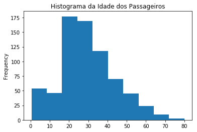

```python
df['idade'].plot(kind='hist', title='Histograma da Idade dos Passageiros');
```

Aqui podemos notar que a maioria dos passageiros presentes no Titanic tinha entre 20 e 30 anos de idade. Além disso podemos ver que a partir dos 30 anos a quantidade de passageiros diminiu ao longo da faixa etária.

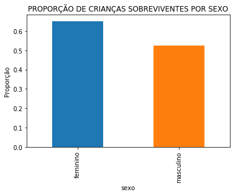

```
sexo
feminino     0.651163
masculino    0.525000
Name: sobreviveu, dtype: float64
```

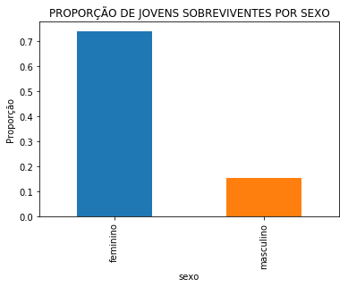

```
sexo
feminino     0.740385
masculino    0.152284
Name: sobreviveu, dtype: float64
```

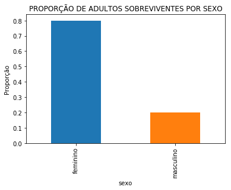

```
sexo
feminino     0.800000
masculino    0.201031
Name: sobreviveu, dtype: float64
```

[figure not shown]

```
sexo
feminino     0.750973
masculino    0.209790
Name: sobreviveu, dtype: float64
```

```python
#Dividindo os dados em faixas etárias
crianca = df[(df['idade'] <= 15)]
jovem = df[(df['idade'] <= 29) & (df['idade'] > 15)]
adulto = df[(df['idade'] <= 59) & (df['idade'] > 29)]
idoso = df[(df['idade'] < 59)]

#agrupando os dados de crianças que sobreviveram
crianca.groupby('sexo')['sobreviveu'].apply(lambda x: np.mean(x == 'sim')).plot(kind='bar')
plt.title('PROPORÇÃO DE CRIANÇAS SOBREVIVENTES POR SEXO')
plt.ylabel('Proporção')
plt.show()
print(crianca.groupby('sexo')['sobreviveu'].apply(lambda x: np.mean(x == 'sim')))

#agrupando os dados de jovens que sobreviveram
jovem.groupby('sexo')['sobreviveu'].apply(lambda x: np.mean(x == 'sim')).plot(kind='bar')
plt.title('PROPORÇÃO DE JOVENS SOBREVIVENTES POR SEXO')
plt.ylabel('Proporção')
plt.show()
print(jovem.groupby('sexo')['sobreviveu'].apply(lambda x: np.mean(x == 'sim')))

#agrupando os dados de adutos que sobreviveram
adulto.groupby('sexo')['sobreviveu'].apply(lambda x: np.mean(x == 'sim')).plot(kind='bar')
plt.title('PROPORÇÃO DE ADULTOS SOBREVIVENTES POR SEXO')
plt.ylabel('Proporção')
plt.show()
print(adulto.groupby('sexo')['sobreviveu'].apply(lambda x: np.mean(x == 'sim')))

#agrupando os dados de idosos que sobreviveram
idoso.groupby('sexo')['sobreviveu'].apply(lambda x: np.mean(x == 'sim')).plot(kind='bar')
plt.title('PROPORÇÃO DE IDOSOS SOBREVIVENTES POR SEXO')
plt.ylabel('Proporção')
plt.show()
print(idoso.groupby('sexo')['sobreviveu'].apply(lambda x: np.mean(x == 'sim')))
```

A faixa etária que não teve um desequilibrio entre sexo foi a das crianças, onde a proporção de sobreviventes estão muito próximas entre os sexos masculino e feminino.

Entre os homens sobreviventes os jovens (entre 15 e 29 anos) foram os que menos sobreviveram (proporcionalmente os jovens presentes do sexo masculino).

#### 4.3 Análise dos Passageiros Gratuitos

Será que todos os gratuitos são tripulantes do Titanic?

Quantos deles sobreviveram?

```python
#passageiros com tarifa zero
gratuito = df[df['tarifa'] == 0.0]
print('Temos que entre todos os passageiros {0} não tiveram sua tarifa cobrada.'.format(gratuito.shape[0]))
gratuito
```

```
Temos que entre todos os passageiros 15 não tiveram sua tarifa cobrada.
```

|  | sobreviveu | classe | nome | sexo | idade | irmaos_conjuges | pais_filhos | tarifa | embarque |
| --- | --- | --- | --- | --- | --- | --- | --- | --- | --- |
| 179 | nao | terceira_classe | Leonard, Mr. Lionel | masculino | 36.0 | 0 | 0 | 0.0 | Southampton |
| 263 | nao | primeira_classe | Harrison, Mr. William | masculino | 40.0 | 0 | 0 | 0.0 | Southampton |
| 271 | sim | terceira_classe | Tornquist, Mr. William Henry | masculino | 25.0 | 0 | 0 | 0.0 | Southampton |
| 277 | nao | segunda_classe | Parkes, Mr. Francis "Frank" | masculino | NaN | 0 | 0 | 0.0 | Southampton |
| 302 | nao | terceira_classe | Johnson, Mr. William Cahoone Jr | masculino | 19.0 | 0 | 0 | 0.0 | Southampton |
| 413 | nao | segunda_classe | Cunningham, Mr. Alfred Fleming | masculino | NaN | 0 | 0 | 0.0 | Southampton |
| 466 | nao | segunda_classe | Campbell, Mr. William | masculino | NaN | 0 | 0 | 0.0 | Southampton |
| 481 | nao | segunda_classe | Frost, Mr. Anthony Wood "Archie" | masculino | NaN | 0 | 0 | 0.0 | Southampton |
| 597 | nao | terceira_classe | Johnson, Mr. Alfred | masculino | 49.0 | 0 | 0 | 0.0 | Southampton |
| 633 | nao | primeira_classe | Parr, Mr. William Henry Marsh | masculino | NaN | 0 | 0 | 0.0 | Southampton |
| 674 | nao | segunda_classe | Watson, Mr. Ennis Hastings | masculino | NaN | 0 | 0 | 0.0 | Southampton |
| 732 | nao | segunda_classe | Knight, Mr. Robert J | masculino | NaN | 0 | 0 | 0.0 | Southampton |
| 806 | nao | primeira_classe | Andrews, Mr. Thomas Jr | masculino | 39.0 | 0 | 0 | 0.0 | Southampton |
| 815 | nao | primeira_classe | Fry, Mr. Richard | masculino | NaN | 0 | 0 | 0.0 | Southampton |
| 822 | nao | primeira_classe | Reuchlin, Jonkheer. John George | masculino | 38.0 | 0 | 0 | 0.0 | Southampton |

Como podemos notar, na tabela acima, que todos os passageiros eram homens cujo a maioria (informada) era adulta.

Outro aspecto que podemos mencionar é que todos embarcaram em Southampton, reforçando ainda mais que esses passageiros gratuitos era tripulantes do navio, pois sairam do ponto inicial. Além do mais que nenhum deles levaram irmãoes/conjuges ou pais/filhos.

Se tratando dos sobreviventes podemos ver que apenas 1 sobreviveu a tragédia.

### 5 Conclusões

A tragédia do Titanic foi, no século XX, o maior e inesperado desastre provocado por um iceberg. Fazendo com que sua hstória até vira-se filme.

Através dessa análise podemos ver qual foi o sexo que deve maior índice de sobreviventes, se a classe da cabine que esses passageiros estavam contribuiu para sua sobrevivencia, se sua idade fez diferença na hora de embarque nos botes salva-vidas. Podemos ver que, embora a classe social ajudou muito, tivemos mortes em todas as classe, tendo num total (conforme analisado somente 891 dados dos mais de 1500 pessoas que morreram, segundo a hstória) 549 pessoas mortas, ou seja 61,62% dos passageiros no Titanic.

O mais interessante nesta análise foi que podemos ver que os passageiros da terceira classe eram os que estavam em maior quantidade no navio (491 passageiros), porém foram os que tiveram a maior proporção de mortos no desastre (só sobreviveram 24,2363% dos passageiros da terceira classe, ou seja, 119 passageiros dos 491).

Como era esperado, mulheres e crianças foram que obtiveram as maiores taxas de sobrevivência. E entre as crianças obtivemos a menor variação entre sexo dos sobreviventes (entre as crianças do sexo feminino 65,1163% sobreviveram e entre as crianças do sexo masculino 52,5000% sobreviveram).

Nesta análise não foi feito um estudo profundo estatítico dos dados, e sim uma análise mais visual quantitativa.

### Limitações

Ao visualizar os dados através da função que mostra a quantidade de dados nulos, obtemos os seguintes resultados:

```
No campo da idade temos 177 valores nulos:
    Para está analise, conforme foi dito anteriormente, foi desconsiderado os dados nulos, para que não havesse interferência externa nos dados, e consequentemente levasse a uma análise errônea.

No campo Cabine temos 687 valores nulos:
    Como esse campo foi desconsiderado em nossa análise, os dados nulos não interferiram em nada.

No campo Embarque temos 2 valores nulos:
    Este campo foi considerado somente na análise dos passageiros gratuitos, e como para esse aspectos todos os embarques estavam preenchidos, os 2 valores nulos não interferiram.
```

### 6 Referências Usadas

https://pt.wikipedia.org/wiki/RMS_Titanic

www.kaggle.com/c/titanic/data

https://www.vooo.pro/insights/guia-basico-para-plotar-graficos-usando-o-matplotlib-do-python/

https://stackoverflow.com/questions/19410042/how-to-make-ipython-notebook-matplotlib-plot-inline

https://matplotlib.org/api/_as_gen/matplotlib.pyplot.plot.html

https://pandas.pydata.org/pandas-docs/version/0.22/